# StrathE2E2 Project

Avinash Pothuri

2026-07-20

## Overview

### Aim

This project develops an optimisation framework for determining fishing gear activity multipliers required to achieve specific harvest ratios within the StrathE2E2 ecosystem model.

The Harvest Ratio is the proportion of average biomass captured per unit time. It is calculated by both Activity and Power of the fishing gear.

## 1 Main Program

### Background

For each fishing guild, the harvest ratio is given by aggregating the contribution of all individual fishing gears. This relationship for the first guilds harvest ratio is shown in Equation 1:

$$A_1 a_1 + B_1 a_2 + \dots + L_1 a_{12} =
HR_1
\tag{1}$$

where:

- $A_1, B_1, \dots, L_1$ represent the contribution from each fishing gear.
- $a_1, a_2, \dots, a_{12}$ are the activity multipliers for fishing gears 1 to 12, respectively.
- $HR_1$ is the total harvest ratio for the first fishing guild.

A similar equation can be found for all 10 fishing guilds, and thus altogether can be written as a matrix equation shown in Equation 2:

$$\mathbf{M} \ \mathbf{x} \ = \ \mathbf{y}
\tag{2}$$

Where **M** represents the contribution matrix, with each row corresponding to a fishing guild and each column corresponding to an individual fishing gear. The vector **x** contains the activity multipliers for the fishing gears, while the vector **y** represents the desired harvest ratios for each fishing guild and defines the optimisation target that the activity multipliers must achieve.

$$\mathbf{M} =
\begin{bmatrix}
A_1 & B_1 & . & . & . & L_1 \\
A_2 & B_2 & . & . & . & L_2 \\
. & . & . & & & . \\
. & . & & . & & . \\
. & . & & & . & . \\
A_{10} & B_{10} & . & . & . & L_{10} \\
\end{bmatrix}
\qquad
\mathbf{x} =
\begin{bmatrix}
a_1 \\
a_2 \\
. \\
. \\
a_{12}
\end{bmatrix}
\qquad
\mathbf{y} =
\begin{bmatrix}
HR_1 \\
HR_2 \\
. \\
. \\
HR_{10}
\end{bmatrix}$$

The program attempts to find the activity multipliers, by setting vector **y** to the target harvest ratios, and then solving equation 2. Although the linear system is underdetermined (10 equations and 12 unknowns), the activity multipliers must be non-negative, which restricts any feasable solution.

### Program Setup

The following code block loads in all relevant libraries.

```r
source("functions.R")

library(nloptr)
library(nnls)
library(bvls)
library(StrathE2E2)

model <- e2e_read("North_Sea","2003-2013")
```

### Generate System of equations

The following code contains functions that generate matrix **M**. This is achieved by setting all activity multipliers $a_2$, $a_3$ … $a_{12}$ to zero while maintaining $a_1$ = 1, and then calculates the resultant harvest ratio values. These calculated value correspond to $A_1$, $A_2$, $A_3$ … $A_{10}$. The process is repeated for each activity multiplier in turn, allowing for matrix **M** to be constructed.

Additionally, the code identifies guilds with all-zero power values, for which a non-zero harvest ratio cannot be obtained. The corresponding rows are subsequently removed from both matrix **M** and the target harvest ratio vector **y**.

```r
find_matrix_M <- function(model) {

  temporary_model <- model

  hr_matrix <- sapply(1:12, function(gear_id) {

    activity <- numeric(12)
    activity[gear_id] <- 1

    temporary_model$data$fleet.model$gear_mult <- activity

    F_calc_func_2(temporary_model)
  })
}

initialize_data <- function(model, target_harvest_ratio) {

  hr_matrix <- find_matrix_M(model)

  zero_hr_guilds <- which(rowSums(hr_matrix != 0) == 0)

  hr_matrix <- hr_matrix[-zero_hr_guilds,]
  target_harvest_ratio <- target_harvest_ratio[-zero_hr_guilds]

  list(
    Equations_Matrix = hr_matrix,
    Target_Harvest_Ratio = target_harvest_ratio,
    zero_hr_guilds = zero_hr_guilds
  )
}
```

### Sum of Residual Squares vs Cosine Similarity

The sum of squared resisiduals (SSR) measures the total squared difference between the predicted and observed values. It is defined as:

$$SSR =
\sum_{i=1}^{n}(y_i-\hat{y}_i)^2$$

where $y_i$ are the target values and $\hat{y}_i$ are the corresponding model predictions. A smaller SSR indicates that the predicted values are numerically closer to the observations. Because the residuals are squared, larger errors are penalised more heavily than smaller ones, making SSR particularly sensitive to outliers.

One advantage of SSR is that it is widely used and supported by many optimisation and statistical packages in R.

In contrast, cosine similarity measures the cosine of the angle between two vectors rather than the distance between them. It is defined as:

$$\cos(\theta) = \frac{y \cdot
\hat{y}}{|y| |\hat{y}|}$$

where **y** and **$\hat{y}$** are the target and predicted vectors, respectively. Cosine similarity ranges from 0 to 1 for non-negative vectors, with value 1 indicating that the vectors have exactly the same direction.

Cosine Similarity thus doesn’t account for the length (magnitude) of the vector, only how closely their directions align.

### Solving System of equations by minimising SSR

One way to solve a system of linear equations in R is to use the **solve()** function. However, **solve()** only works when the the coefficient matrix, **A**, is square, non-singular, and the system has an exact solution. In this case the coefficient matrix is not square and an exact solution does not always exist.

Instead, the solution can be approximated by minimizing the sum of squared residuals. Additionally,the activity multipliers are constrained to be non-negative, as negative values are not physically meaningful.

To find the exact solution (when on exists), or the closest non-negative approximation, the program uses the nnls package in R, which implements the Lawson-Hanson algorithm for No-Negative Least Squares (NNLS). This algorithm finds vector **x** that minimises the sum of squared residuals while satisfying the non-negativity constraint **x** $\geq$ 0:

$$\min_{x \geq
0}\sum_{i=1}^{n}(Ax_i-y_i)^2$$

where **A** is the coefficient matrix, **x** is the vector of activity multipliers, and **y** is the target harvest ratio vector.

```r
solve_nnls <- function(M, y) {

  solution <- nnls(M, y)

  list(
    x = coef(solution),
    SSR = sum(residuals(solution)^2)
  )
}
```

### Solving System of equations by maximising cosine similarity

Cosine Similarity is defined as the cosine of the angle between two vectors, where a value of 1 indicates that the vectors point in the same direction, 0 indicates orthogonality and -1 indicates opposite directions.

For two vectors x and y, cosine similarity in R is implemented below:

```r
cosine_similarity <- function(x, y) {
  norm_x <- sqrt(sum(x^2))
  norm_y <- sqrt(sum(y^2))

  cos_sim <- sum(x * y) / (norm_x * norm_y)
  return(cos_sim)
}
```

Instead of solving
$$Ax=y$$
directly, this program finds x by searching for x where the cosine similarity between **Ax** and **y** is maximised

$$f(x) = \frac{Ax \cdot y}{|Ax|
|y|}$$
Since |y| is constant with respect to x, this is equivalent to solving:

$$f(x) = \max_{x \geq 0} \frac{(Ax)^T
y}{|Ax|}$$

The optimisation is done using the nloptr library with the NLOPT_LD_SLSQP algorithm, a gradient-based constrained optimisation method, which was found to be the most efficient and accurate. The gradient of the objective function is:

$$\nabla_x f(x) = A^T
\left(\frac{y}{\|Ax\|} - \frac{((Ax)^T y)Ax}{\|Ax\|^3}
\right)$$

The expression is found by using the chain rule to the cosine similarity objective.

```r
solve_maximise_cosine_similarity <- function(A, b) {

  cos_obj <- function(x) {
    Ax <- A %*% x
    -sum(Ax * b) / sqrt(sum(Ax^2))
  }

  cos_grad <- function(x) {
    Ax <- A %*% x
    s <- sqrt(sum(Ax^2))

    as.vector(
      t(A) %*% (-b / s + (sum(Ax * b) / s^3) * Ax)
    )
  }

  x <- nloptr(
    x0 = rep(1, ncol(A)),
    eval_f = cos_obj,
    eval_grad_f = cos_grad,
    lb = rep(0, ncol(A)),
    opts = list(
      algorithm = "NLOPT_LD_SLSQP",
      maxeval = 10000,
      xtol_rel = 1e-12
    )
  )

  Ax <- A %*% x$solution
  c <- sqrt(sum(b^2)) / sqrt(sum(Ax^2))

  c * x$solution
}
```

### Analysis Functions

These funcions are used to analyse the solver functions.

```r
ssr <- function(A, x, b) {
  sum((A %*% x - b)^2)
}

relative_ssr_Ax <- function(A, x, y) {
  Ax <- A %*% x
  sum((Ax - y)^2) / sum(Ax^2)
}

find_modified_hr <- function(temperary_model, modified_activity_multiplier) {
  temperary_model$data$fleet.model$gear_mult <- modified_activity_multiplier
  F_calc_func_2(temperary_model)
}

check_if_exact_solution <- function(final_activity_multiplier, harvest_ratio_matrix, target_harvest_ratio) {
  residual <- target_harvest_ratio - harvest_ratio_matrix %*% final_activity_multiplier
  tolerance = 1e-10
  norm(residual, type = "2") < tolerance
}
```

### Analysis

```r
Target_Harvest_Ratio <- F_calc_func_2(model) * runif(10, min = 0, max = 1000)

hr_data <- initialize_data(model, Target_Harvest_Ratio)

A <- hr_data$Equations_Matrix
b <- hr_data$Target_Harvest_Ratio


print("NNLS Method")
```

```
## [1] "NNLS Method"
```

```r
x <- solve_nnls(A, b)

b_hat <- A %*% x$x

print(cosine_similarity(b, b_hat))
```

```
## [1] 0.9926483
```

```r
print(ssr(A, x$x, b))
```

```
## [1] 0.00292927
```

```r
print(relative_ssr_Ax(A, x$x, b))
```

```
## [1] 0.0148672
```

```r
print("Cos Sim Method")
```

```
## [1] "Cos Sim Method"
```

```r
x <- solve_maximise_cosine_similarity(A, b)

b_hat <- A %*% x

print(cosine_similarity(b, b_hat))
```

```
## [1] 0.9926483
```

```r
print(ssr(A, x, b))
```

```
## [1] 0.002940078
```

```r
print(relative_ssr_Ax(A, x, b))
```

```
## [1] 0.01470345
```

## 2 Sensitivity Analysis of Harvest Ratio Constraints

This section examines the sensitivity and robustness of the optimisation model by evaluating how changes to harvest ratio constraints influence solution accuracy. A series of analyses were performed to determine how the removal of individual constraints, modification of target harvest ratios, and simultaneous changes to multiple targets affect the ability of the non-negative least squares (NNLS) algorithm and the maximum cosine similarity method to identify solutions that satisfy the model constraints. These analyses provide insight into the relative importance of individual harvest ratio constraints and the conditions under which exact solutions can be achieved.

The following code initialises the data required for this section. A randomly perturbed target harvest ratio was generated to provide an alternative starting condition for the sensitivity analysis.

```r
Target_Harvest_Ratio <- F_calc_func_2(model) * runif(10, 0, 2)

hr_data <- initialize_data(model, Target_Harvest_Ratio)

excluded_guilds <- hr_data$zero_hr_guilds
available_guilds <- setdiff(1:10, excluded_guilds)

grouplabels <- c(
    "Planktivorous fish",
    "Demersal fish",
    "Migratory fish",
    "Benthos_susp-dep",
    "Benthos_carn-scav",
    "Zooplankton_carn",
    "Birds",
    "Pinnipeds",
    "Cetaceans",
    "Macrophytes"
  )

grouplabels <- setdiff(grouplabels, excluded_guilds)
```

### Effect of Removing Harvest Ratio Constraints on Solution Accuracy

To investigate the conditions under which the model produced an exact solution, a sensitivity analysis was performed by systematically removing individual harvest ratio constraints and rerunning the program. The purpose was to determine how the availability of constraints influences the ability of the nnls algorithm to find an exact solution.

The program was run multiple times, with one harvest ratio condition removed during each run while all other model parameters were kept unchanged. For each scenario, the resultant solution was evaluated using the Sum of Squared Residuals (SSR). A value of SSR equal to zero indicates that the model was able to find an exact solution. Conversely, a non-zero SSR indicates that an exact solution is impossible to be achieved and that the algorithm identified the closest non-negative least-squares solution instead.

The resulting SSR values were plotted against the harvest ratio condition removed to visualise how each constraint influenced the solvability of the system. This bar graph is shown below:

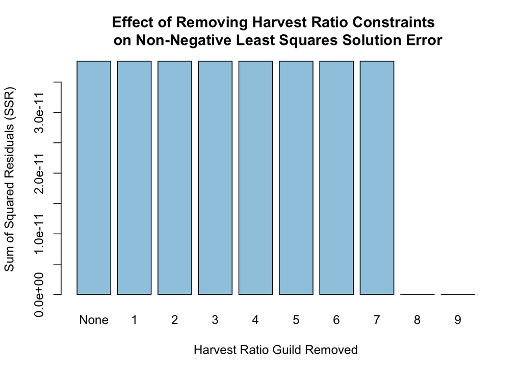

```r
guild_labels <- c("None", available_guilds)

ssr_values <- sapply(c(0, available_guilds), function(i) {

  if (i == 0) {
    Equations_Matrix <- hr_data$Equations_Matrix
    Target_HR <- hr_data$Target_Harvest_Ratio
  } else {
    Equations_Matrix <- hr_data$Equations_Matrix[-i, ]
    Target_HR <- hr_data$Target_Harvest_Ratio[-i]
  }

  nnls <- solve_nnls(Equations_Matrix, Target_HR)
  nnls$SSR

})


barplot(ssr_values,
        col = "#9ECAE1",
        names.arg = guild_labels,
        main = "Effect of Removing Harvest Ratio Constraints \n on Non-Negative Least Squares Solution Error",
        xlab = "Harvest Ratio Guild Removed",
        ylab = "Sum of Squared Residuals (SSR)")
```

### Sensitivity to Changes in the Target Harvest Ratio

To investigate how sensitive the optimisation is to changes in the target harvest ratio, each guild was examined individually. The aim was to determine how altering the target harvest ratio for a single guild affects the quality of the best-fitting solution.

First, the original harvest ratios were calculated and used as the baseline target harvest ratios. For each guild in turn, its target harvest ratio was varied across a range of values while the target harvest ratios for all other guilds were kept fixed.

The figures below show how the SSR changes as the target harvest ratio for each guild is varied. The verticle red dashed line indicates the original harvest ratio for that guild. Lower SSR values indicate solutions that remain close to the original harvest ratios, while larger values indicate that the modified target harvest ratio is increasingly difficult to satisfy without deviating from the original solution.

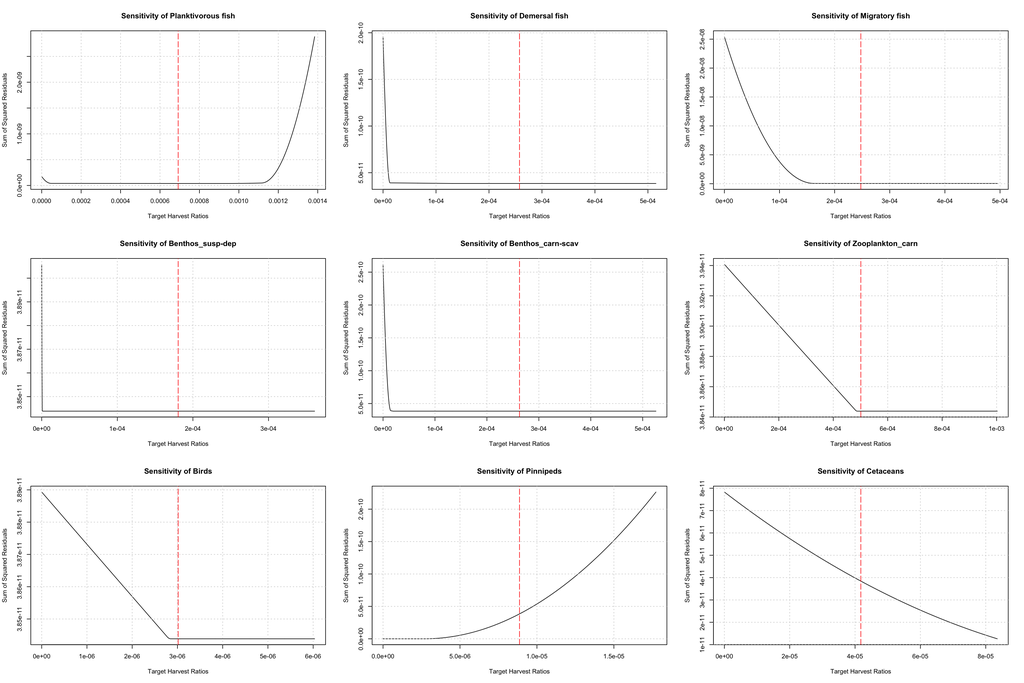

```r
par(mfrow = c(3, 3))

for (i in 1:length(available_guilds)) {

  original_target <- hr_data$Target_Harvest_Ratio

  x_values <- seq(0, original_target[i]*2, length.out =1000)

  y_values <- sapply(x_values, function(value) {

    modified_targets <- hr_data$Target_Harvest_Ratio
    modified_targets[i] <- value

    nnls <- solve_nnls(hr_data$Equations_Matrix, modified_targets)
    SSR <- nnls$SSR
  })

  plot(
    x_values,
    y_values,
    type = "l",
    main = paste("Sensitivity of", grouplabels[i]),
    xlab = "Target Harvest Ratios",
    ylab = "Sum of Squared Residuals",
  )

  abline(v = original_target[i], col = "red", lty = 5)
  grid()
}
```

This sensitivity analysis was repeated using the maximum cosine similarity approach.

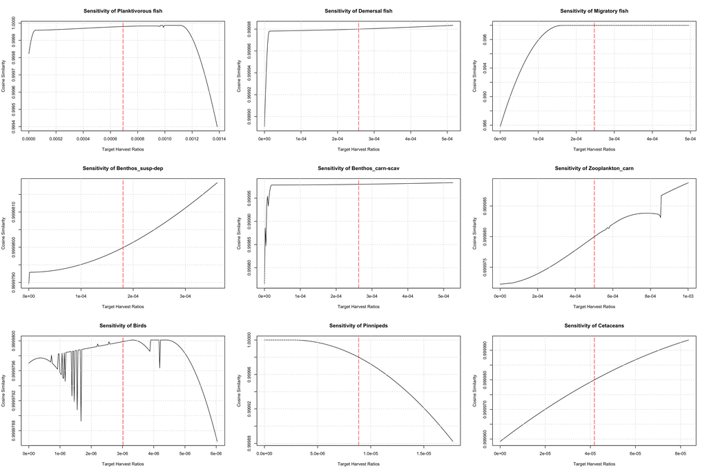

```r
par(mfrow = c(3, 3))

M <- hr_data$Equations_Matrix

for (i in 1:length(available_guilds)) {

  original_target <- hr_data$Target_Harvest_Ratio

  x_values <- seq(0, original_target[i]*2, length.out = 250)

  y_values <- sapply(x_values, function(value) {

    modified_targets <- hr_data$Target_Harvest_Ratio
    modified_targets[i] <- value

    x <- solve_maximise_cosine_similarity(M, modified_targets)
    sol <- M %*% x
    cosine <- cosine_similarity(sol, modified_targets)
  })

  plot(
    x_values,
    y_values,
    type = "l",
    main = paste("Sensitivity of", grouplabels[i]),
    xlab = "Target Harvest Ratios",
    ylab = "Cosine Similarity",
  )

  abline(v = original_target[i], col = "red", lty = 5)
  grid()
}
```

### Sensitivity to Changes in the Target Harvest Ratio On the same graph

To allow direct comparison between guilds, the sensitivity curves were combined onto a single graph. Each line represents the response of optimisation to changes in the target harvest ratio of one guild while all other guild targets remain fixed.

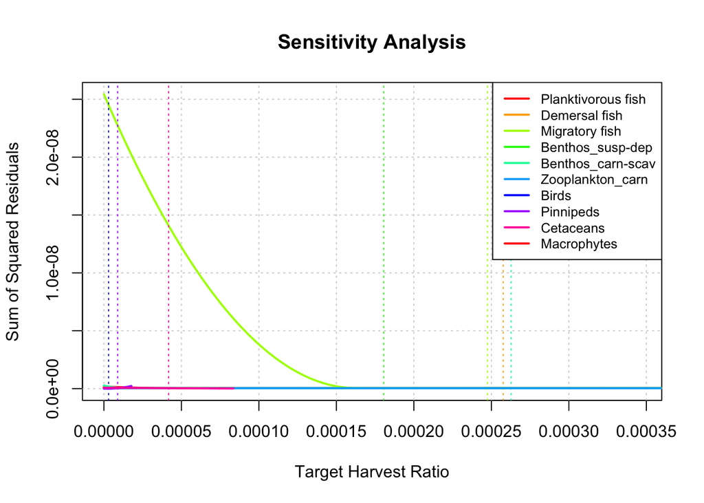

```r
cols <- rainbow(length(available_guilds))

max_x <- max(hr_data$Target_Harvest_Ratio) * 0.5

results <- vector("list", length(available_guilds))
max_y <- 0

for (i in seq_along(available_guilds)) {

  original_target <- hr_data$Target_Harvest_Ratio

  x_values <- seq(0, original_target[i] * 2, length.out = 1000)

  y_values <- sapply(x_values, function(value) {

    modified_targets <- original_target
    modified_targets[i] <- value

    nnls <- solve_nnls(hr_data$Equations_Matrix, modified_targets)
    nnls$SSR
  })

  results[[i]] <- list(x = x_values, y = y_values)
  max_y <- max(max_y, y_values)
}


plot(
  NA,
  xlim = c(0, max_x),
  ylim = c(0, max_y),
  xlab = "Target Harvest Ratio",
  ylab = "Sum of Squared Residuals",
  main = "Sensitivity Analysis",
  type = "n"
)

grid()


for (i in seq_along(available_guilds)) {
  lines(
    results[[i]]$x,
    results[[i]]$y,
    col = cols[i],
    lwd = 2
  )

  abline(
    v = hr_data$Target_Harvest_Ratio[i],
    col = cols[i],
    lty = 3
  )
}

legend(
  "topright",
  legend = grouplabels,
  col = cols,
  lwd = 2,
  cex = 0.8
)
```

### 2 Variable Sensitivity Analysis

To examine interactions between guild targets, a two-variable sensitivity analysis was performed. Instead of changing one target harvest ratio at a time, the target harvest ratios of two guilds were varied simultaneously while all other guild targets were held constant.

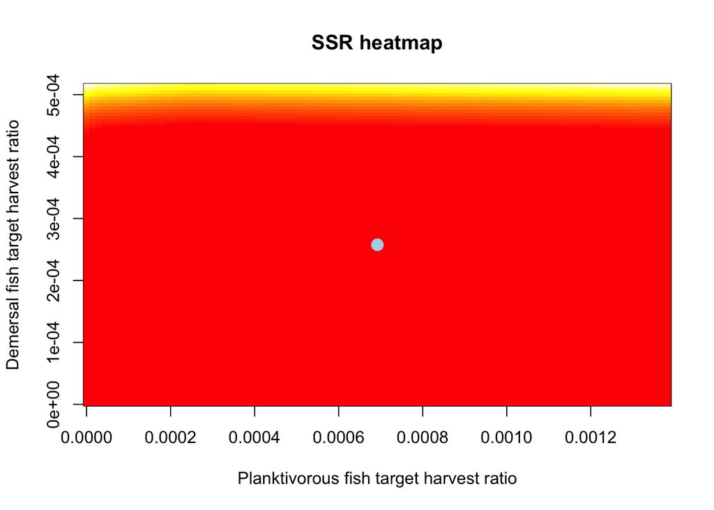

```r
index1_values <- seq(0, hr_data$Target_Harvest_Ratio[1]*2, length.out = 100)
index2_values <- seq(0, hr_data$Target_Harvest_Ratio[2]*2, length.out = 100)

output_matrix <- matrix(
  nrow = length(index2_values),
  ncol = length(index1_values)
)

for (i in seq_along(index1_values)) {
  for (j in seq_along(index2_values)) {

    temp_thr <- hr_data$Target_Harvest_Ratio

    temp_thr[1] <- index1_values[i]
    temp_thr[2] <- index2_values[j]

    nnls <- solve_nnls(hr_data$Equations_Matrix, temp_thr)
    output_matrix[j, i] <- nnls$SSR
  }
}

cols <- heat.colors(100)

image(
  x = index1_values,
  y = index2_values,
  z = output_matrix,
  col = cols,
  xlab = "Planktivorous fish target harvest ratio",
  ylab = "Demersal fish target harvest ratio",
  main = "SSR heatmap"
)

points(
  hr_data$Target_Harvest_Ratio[1],
  hr_data$Target_Harvest_Ratio[2],
  pch = 19,
  col = "lightblue",
  cex = 1.5
)
```

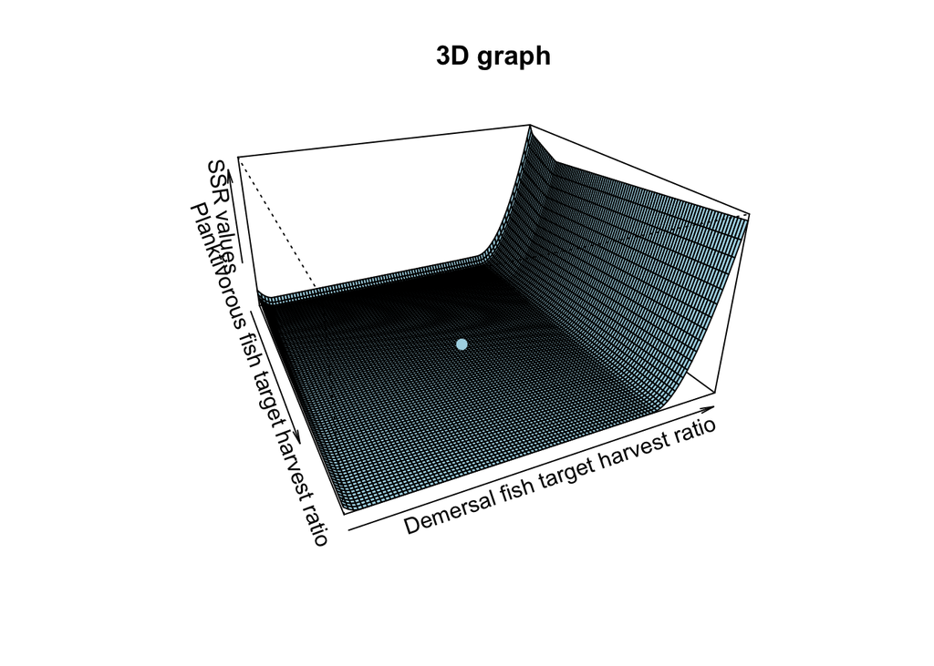

```r
graph <- persp(
  x = index1_values,
  y = index2_values,
  z = output_matrix,
  theta = 65,
  phi = 25,
  expand = 0.5,
  col = "lightblue",
  xlab = "Planktivorous fish target harvest ratio",
  ylab = "Demersal fish target harvest ratio",
  zlab = "SSR values",
  main = "3D graph"
)

Harvest_Ratio <- hr_data$Target_Harvest_Ratio
point_z <-  solve_nnls(hr_data$Equations_Matrix, Harvest_Ratio)$SSR

points(
  trans3d(Harvest_Ratio[1], Harvest_Ratio[2], point_z, graph),
  col = "lightblue",
  pch = 19,
  cex = 1
)
```

## 3 Bounded Least Squared Optimisation

One limitation of the original optimisation was that some of the resulting activity multipliers were unrealistically large. To address this issue, the optimisation procedure were modified by incorporating the bvls package, which allows upper bounds to be specified for individual activity multipliers. This constrains the optimisation solution to be a more realistic range and prevents excessively large multiplier values from influencing the results.

The following code defines the optimisation function using the bvls package. The function applies the bounded least squares approach to find the activity multipliers that minimise the residual error while ensuring that each multiplier remains within its specified upper and lower limits.

```r
upper_bound_solution <- function(M, y, upper_bound) {

  lower_bound <- rep(0, 12)

  fit <- bvls(
    M,
    y,
    bl = lower_bound,
    bu = upper_bound
  )

  list(
    x = coef(fit),
    SSR = sum(residuals(fit)^2)
  )
}
```

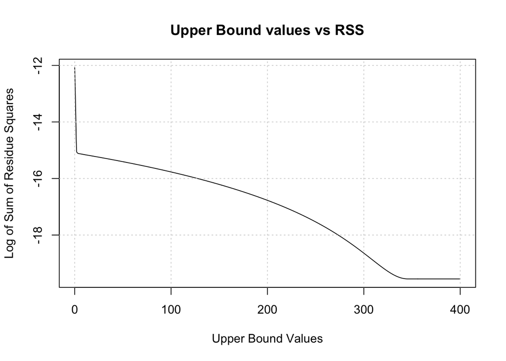

```r
Target_Harvest_Ratio <- c(0.0001, 0.0004, 0.002, 0.0004, 0.0003, 0.0005, 0.00008, 0.000002, 0.001, 0)

hr_data <- initialize_data(model, Target_Harvest_Ratio)

M <- hr_data$Equations_Matrix
y <- hr_data$Target_Harvest_Ratio

x_values <- seq(0, 400, length.out = 1000)

y_values <- sapply(x_values, function(upper_bound) {
  upper_bound_solution(M, y, rep(upper_bound, 12))$SSR
})

log_y <- lapply(y_values, log)

plot(x_values, log_y,
     type = "l",
     xlab = "Upper Bound Values",
     ylab = "Log of Sum of Residue Squares",
     main = "Upper Bound values vs RSS")

SSR <- solve_nnls(M, y)$SSR

# abline(h = log(SSR), col = "red", lty = 5, lwd = 2)

grid()
```